# Rowley - VWR - Phonological Priming

```r
library(tidyverse)
library(DT)
library(lme4)
library(scales)
library(broom)
library(sjPlot)
library(sjmisc)
```

# Deaf v. Hearing

## Load data

We’ll load the data from the CSV we created in `00_clean_data.R` and remove:

1. All rows with RTs < 250 or > 1200 using the `exclude_too_fast_slow` flag
2. All non-word trials
3. Words: BADE, DUES, FOB, NORSE, VAT, WAIF
4. Subjects 9, 10, 32, 61

Below is a sample of that dataset:

```r
df <- read_csv("data/cleaned_dataset.csv") %>%
  filter(exclude_too_fast_slow == 0) %>%
  filter(word_type != 'Nonword') %>%
  filter(!(target_trial %in% c('BADE', 'DUES', 'FOB', 'NORSE', 'VAT', 'WAIF'))) %>%
  filter(!(subject %in% c(9, 10, 32, 61))) %>%
  mutate_at(vars(group, subject), factor) %>%
  rename(rt = reaction_time)

df %>%
  head() %>%
  datatable(options = list(dom = 't'))
```

|  | subject | age | data_file_basename | group | handedness | session_date | session_start_date_time_utc | sex | block | choose_which_list | choose_which_list_cycle | choose_which_list_sample | correct_response_block | mask_block | practice_list | practice_list_cycle | practice_list_sample | prime_block | prime_displayed_onset_to_onset_time_block | procedure_block | running_block | target_block | target_displayed_acc_block | target_displayed_cresp_block | target_displayed_duration_error_block | target_displayed_onset_delay_block | target_displayed_onset_time_block | target_displayed_onset_to_onset_time_block | target_displayed_resp_block | … |
| --- | --- | --- | --- | --- | --- | --- | --- | --- | --- | --- | --- | --- | --- | --- | --- | --- | --- | --- | --- | --- | --- | --- | --- | --- | --- | --- | --- | --- | --- | --- |
| 1 | 1 | 34 | Masked Priming Lexical Decision Task-1-1 | 1 | right | 11-21-2014 | 2014-11-21T17:32:00Z | male | 21 | 1 | 1 | 1 |  |  |  |  |  |  |  | RunListA | ChooseWhichList |  |  |  |  |  |  |  |  | … |
| 2 | 1 | 34 | Masked Priming Lexical Decision Task-1-1 | 1 | right | 11-21-2014 | 2014-11-21T17:32:00Z | male | 21 | 1 | 1 | 1 |  |  |  |  |  |  |  | RunListA | ChooseWhichList |  |  |  |  |  |  |  |  | … |
| 3 | 1 | 34 | Masked Priming Lexical Decision Task-1-1 | 1 | right | 11-21-2014 | 2014-11-21T17:32:00Z | male | 21 | 1 | 1 | 1 |  |  |  |  |  |  |  | RunListA | ChooseWhichList |  |  |  |  |  |  |  |  | … |
| 4 | 1 | 34 | Masked Priming Lexical Decision Task-1-1 | 1 | right | 11-21-2014 | 2014-11-21T17:32:00Z | male | 21 | 1 | 1 | 1 |  |  |  |  |  |  |  | RunListA | ChooseWhichList |  |  |  |  |  |  |  |  | … |
| 5 | 1 | 34 | Masked Priming Lexical Decision Task-1-1 | 1 | right | 11-21-2014 | 2014-11-21T17:32:00Z | male | 21 | 1 | 1 | 1 |  |  |  |  |  |  |  | RunListA | ChooseWhichList |  |  |  |  |  |  |  |  | … |
| 6 | 1 | 34 | Masked Priming Lexical Decision Task-1-1 | 1 | right | 11-21-2014 | 2014-11-21T17:32:00Z | male | 21 | 1 | 1 | 1 |  |  |  |  |  |  |  | RunListA | ChooseWhichList |  |  |  |  |  |  |  |  | … |

## Subject-Level Data

Let’s take a look at our participants that we didn’t remove:

```r
df %>%
  select(subject, age, group, handedness, sex, vw_rs) %>%
  distinct() %>%
  group_by(group) %>%
  summarise(participants = n(),
            age = round(mean(age), 1),
            vw_rs = round(mean(vw_rs), 1),
            male = sum(if_else(sex == 'male', 1, 0)),
            female = sum(if_else(sex == 'female', 1, 0)),
            right_handed = sum(if_else(handedness == 'right', 1, 0)),
            left_handed = sum(if_else(handedness == 'left', 1, 0))) %>%
  datatable(options = list(dom = 't'))
```

|  | group | participants | age | vw_rs | male | female | right_handed | left_handed |
| --- | --- | --- | --- | --- | --- | --- | --- | --- |
| 1 | 1 | 18 | 31.1 | 33.1 | 7 | 11 | 15 | 3 |
| 2 | 2 | 18 | 29.5 | 32.1 | 7 | 11 | 17 | 1 |

And their reaction time:

```r
# First calculate subject-level dataset
subject_level <- df %>%
  group_by(group, subject, prime_type, word_type) %>%  # Subject-level
  summarise(accuracy = mean(accuracy),
            rt = mean(rt),
            vw_rs = mean(vw_rs))

# Reaction time on group level
subject_level %>%
  group_by(group, prime_type, word_type) %>%  # Group-level
  summarise(rt = mean(rt)) %>%
  spread(word_type, rt) %>%
  ungroup() %>%
  mutate_if(is.numeric, round, 1) %>%
  datatable(options = list(dom = 't'))
```

|  | group | prime_type | Word |
| --- | --- | --- | --- |
| 1 | 1 | Graphemic | 624.7 |
| 2 | 1 | Phonological | 617.5 |
| 3 | 2 | Graphemic | 631.2 |
| 4 | 2 | Phonological | 624.9 |

And their accuracy:

```r
# Accuracy on group level
subject_level %>%
  group_by(group, prime_type, word_type) %>%  # Group-level
  summarise(accuracy = mean(accuracy)) %>%
  spread(word_type, accuracy) %>%
  ungroup() %>%
  mutate_if(is.numeric, percent, .1) %>%
  datatable(options = list(dom = 't'))
```

|  | group | prime_type | Word |
| --- | --- | --- | --- |
| 1 | 1 | Graphemic | 97.4% |
| 2 | 1 | Phonological | 98.9% |
| 3 | 2 | Graphemic | 95.2% |
| 4 | 2 | Phonological | 96.4% |

## Visualization

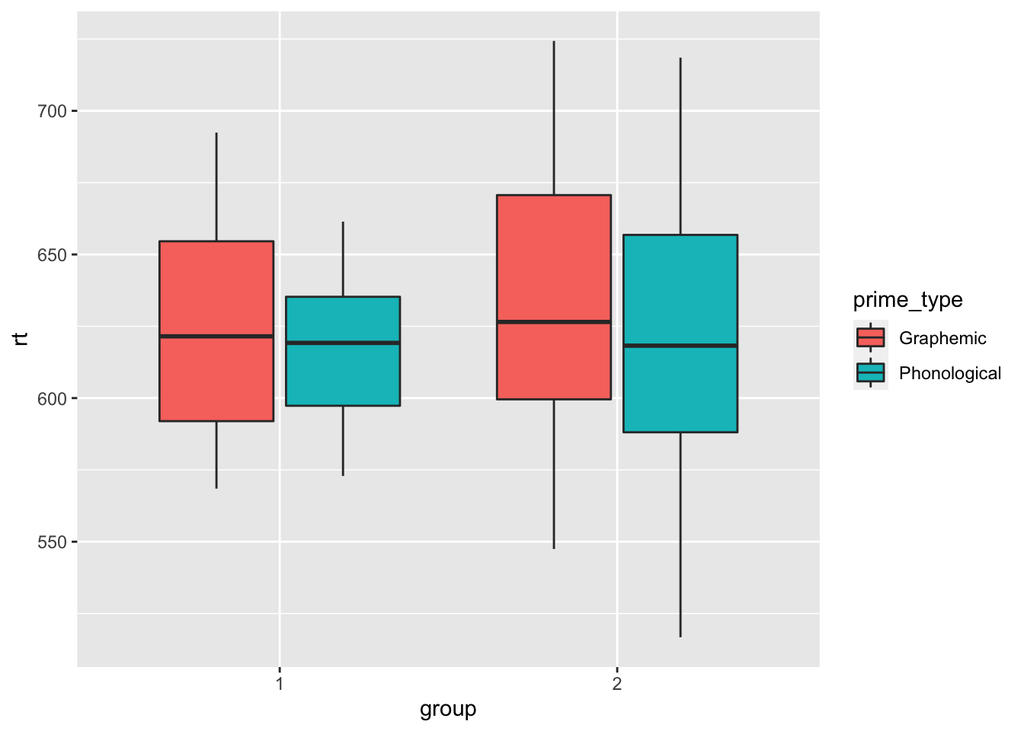

```r
subject_level %>%
  ggplot(aes(x = group, y = rt, fill = prime_type)) +
  geom_boxplot() +
  scale_y_continuous()
```

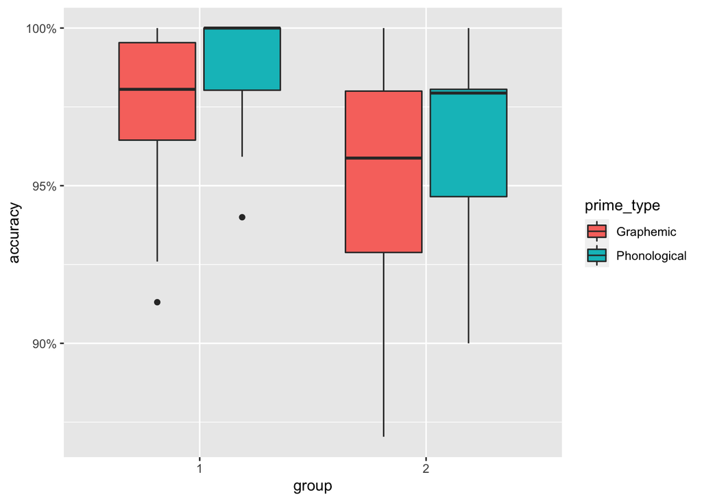

```r
subject_level %>%
  ggplot(aes(x = group, y = accuracy, fill = prime_type)) +
  geom_boxplot() +
  scale_y_continuous(labels = percent_format(1))
```

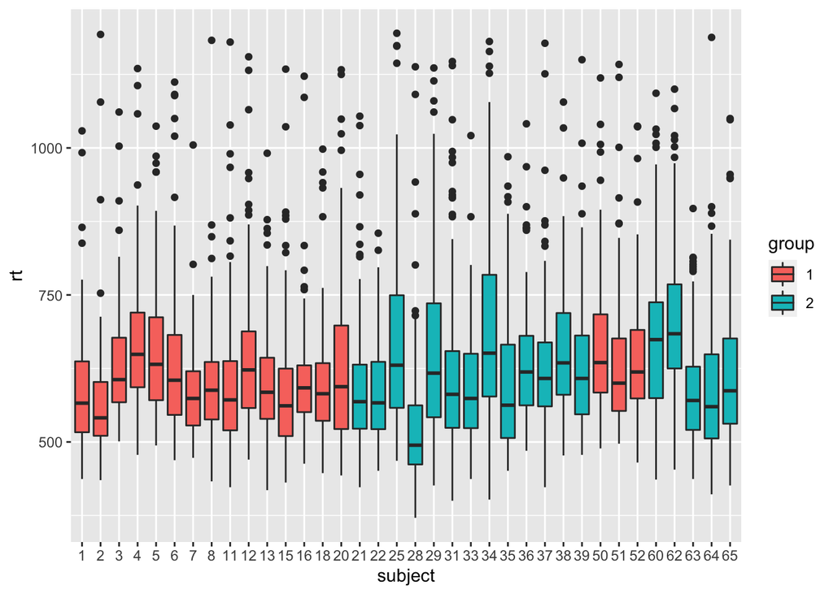

```r
df %>%
  ggplot(aes(x = subject, y = rt, fill = group)) +
  geom_boxplot()
```

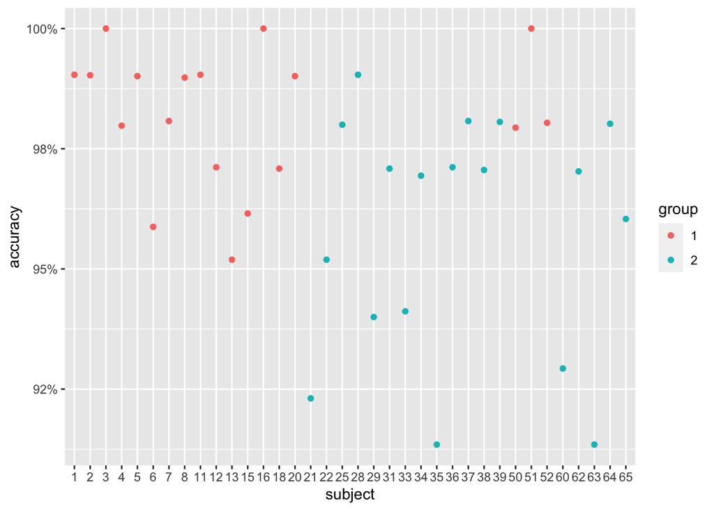

```r
df %>%
  group_by(group, subject) %>%
  summarise(accuracy = mean(accuracy)) %>%
  ggplot(aes(x = subject, y = accuracy, color = group)) +
  geom_point() +
  scale_y_continuous(labels = percent_format(1))
```

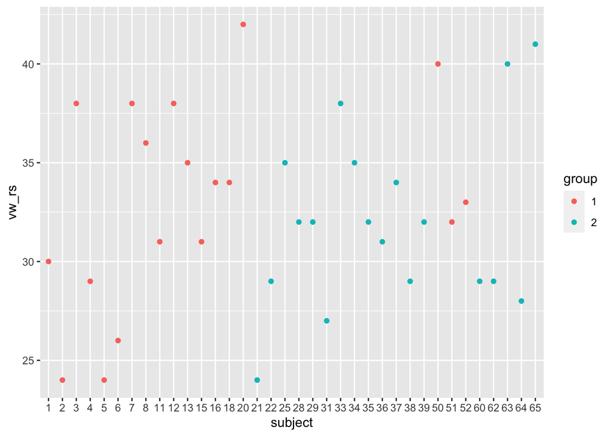

```r
df %>%
  group_by(group, subject) %>%
  summarise(vw_rs = mean(vw_rs)) %>%
  ggplot(aes(x = subject, y = vw_rs, color = group)) +
  geom_point()
```

### With Reading Scores

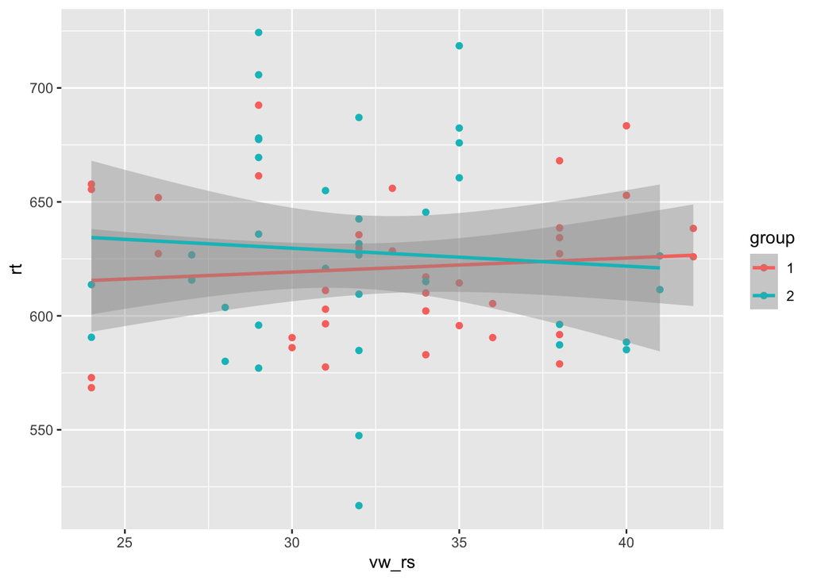

```r
subject_level %>%
  ggplot(aes(x = vw_rs, y = rt, color = group)) +
  geom_point() +
  geom_smooth(method = 'lm')
```

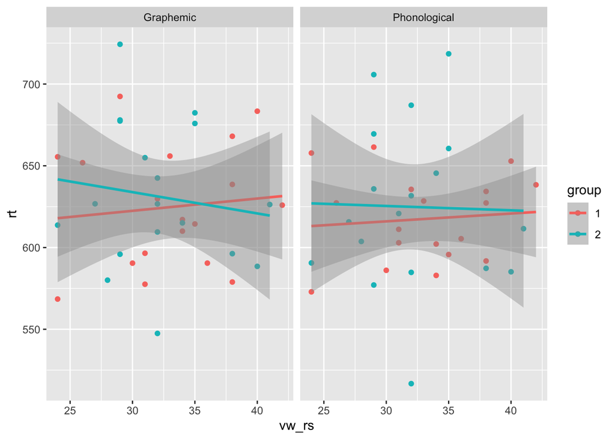

```r
subject_level %>%
  ggplot(aes(x = vw_rs, y = rt, color = group)) +
  geom_point() +
  geom_smooth(method = 'lm') +
  facet_wrap("prime_type")
```

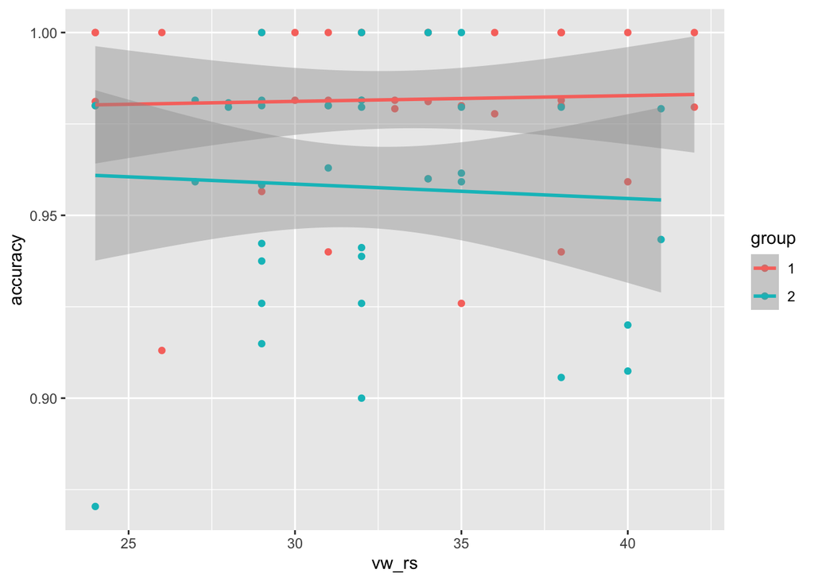

```r
subject_level %>%
  ggplot(aes(x = vw_rs, y = accuracy, color = group)) +
  geom_point() +
  geom_smooth(method = 'lm')
```

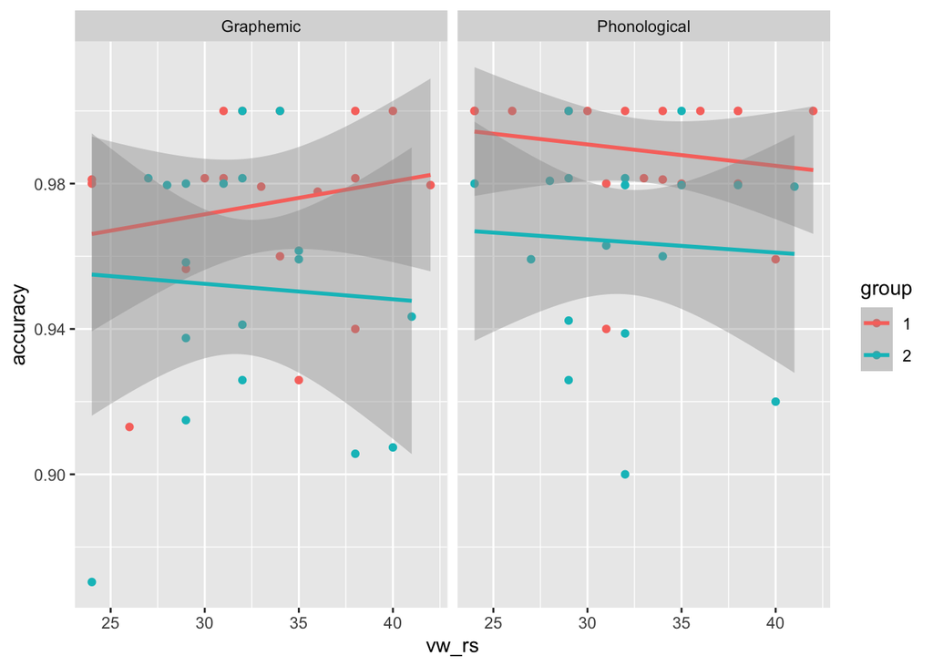

```r
subject_level %>%
  ggplot(aes(x = vw_rs, y = accuracy, color = group)) +
  geom_point() +
  geom_smooth(method = 'lm') +
  facet_wrap("prime_type")
```

## Modeling

To set up our linear mixed effects (also called hierarchical regression, multilevel models, etc.) we need to decide what are the fixed effects (the ones we are interested in) and what are the random effects (what we are not interested in, but which variance should be accounted for in our model).

Models for:

1. Reaction time
2. Accuracy

In each model, the fixed effects are:

1. Group (deaf/hearing)
2. Prime Type (phonological/graphemic)

And the random effects are:

### Reaction Time Model

```r
rt_model <- lmer(data = df, rt ~ group * prime_type + running_trial +
                                 (1|subject) + (1|target_trial))

tab_model(rt_model)
```

|  | rt |  |  |
| --- | --- | --- | --- |
| Predictors | Estimates | CI | p |
| (Intercept) | 615.52 | 590.68 – 640.36 | **<0.001** |
| group [2] | 9.21 | -17.33 – 35.76 | 0.496 |
| prime_type [Phonological] | -6.35 | -16.85 – 4.15 | 0.236 |
| running_trial [ListB] | 16.20 | -9.29 – 41.68 | 0.213 |
| group [2] * prime_type [Phonological] | -0.80 | -15.68 – 14.08 | 0.916 |
| Random Effects |  |  |  |
| σ<sup>2</sup> | 13080.36 |  |  |
| τ<sub>00</sub> <sub>target_trial</sub> | 1883.22 |  |  |
| τ<sub>00</sub> <sub>subject</sub> | 1374.69 |  |  |
| ICC | 0.20 |  |  |
| N <sub>subject</sub> | 36 |  |  |
| N <sub>target_trial</sub> | 104 |  |  |
| Observations | 3673 |  |  |
| Marginal R<sup>2</sup> / Conditional R<sup>2</sup> | 0.005 / 0.204 |  |  |

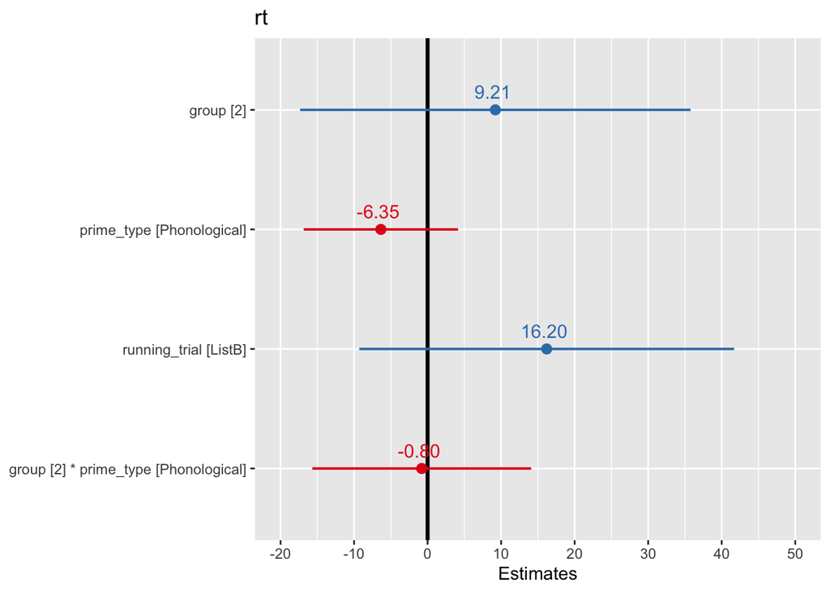

```r
plot_model(rt_model, vline.color = 'black',  show.values = TRUE)
```

### Accuracy Model

```r
acc_model <- lmer(data = df, accuracy ~ group * prime_type + running_trial +
                                 (1|subject) + (1|target_trial))

tab_model(acc_model)
```

|  | accuracy |  |  |
| --- | --- | --- | --- |
| Predictors | Estimates | CI | p |
| (Intercept) | 0.97 | 0.96 – 0.99 | **<0.001** |
| group [2] | -0.02 | -0.04 – -0.01 | **0.008** |
| prime_type [Phonological] | 0.01 | -0.00 – 0.03 | 0.079 |
| running_trial [ListB] | 0.01 | -0.01 – 0.02 | 0.346 |
| group [2] * prime_type [Phonological] | -0.00 | -0.02 – 0.02 | 0.922 |
| Random Effects |  |  |  |
| σ<sup>2</sup> | 0.03 |  |  |
| τ<sub>00</sub> <sub>target_trial</sub> | 0.00 |  |  |
| τ<sub>00</sub> <sub>subject</sub> | 0.00 |  |  |
| ICC | 0.07 |  |  |
| N <sub>subject</sub> | 36 |  |  |
| N <sub>target_trial</sub> | 104 |  |  |
| Observations | 3673 |  |  |
| Marginal R<sup>2</sup> / Conditional R<sup>2</sup> | 0.007 / 0.072 |  |  |

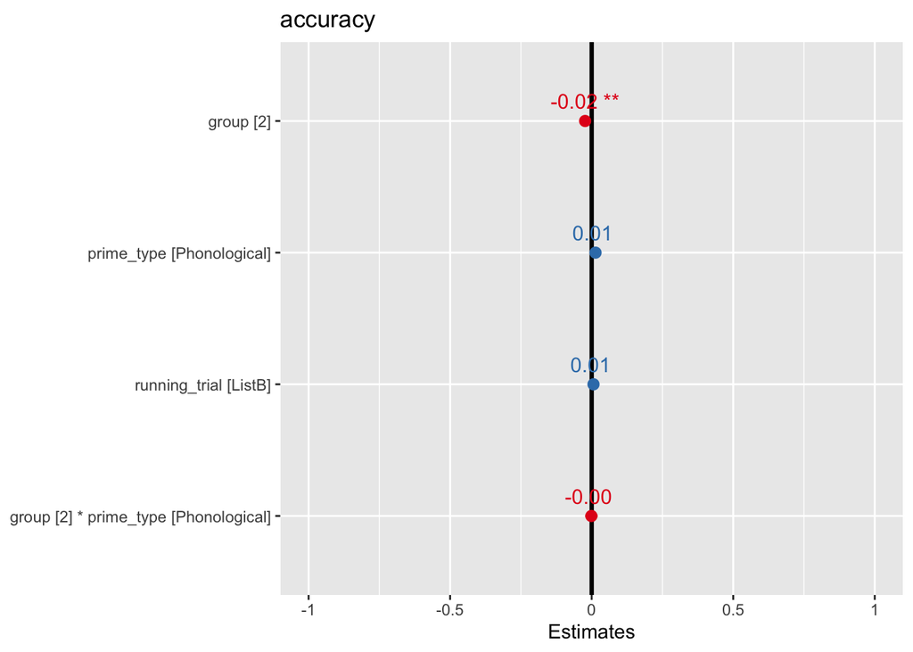

```r
plot_model(acc_model, vline.color = 'black',  show.values = TRUE)
```

### Reaction Time Model with vw_rs

```r
rt_model <- lmer(data = df, rt ~ group * prime_type + running_trial + vw_rs +
                                 (1|subject) + (1|target_trial))

tab_model(rt_model)
```

|  | rt |  |  |
| --- | --- | --- | --- |
| Predictors | Estimates | CI | p |
| (Intercept) | 609.02 | 513.97 – 704.06 | **<0.001** |
| group [2] | 9.43 | -17.66 – 36.52 | 0.495 |
| prime_type [Phonological] | -6.35 | -16.85 – 4.14 | 0.236 |
| running_trial [ListB] | 16.39 | -9.63 – 42.41 | 0.217 |
| vw_rs | 0.19 | -2.53 – 2.92 | 0.889 |
| group [2] * prime_type [Phonological] | -0.80 | -15.68 – 14.08 | 0.916 |
| Random Effects |  |  |  |
| σ<sup>2</sup> | 13080.36 |  |  |
| τ<sub>00</sub> <sub>target_trial</sub> | 1883.22 |  |  |
| τ<sub>00</sub> <sub>subject</sub> | 1420.69 |  |  |
| ICC | 0.20 |  |  |
| N <sub>subject</sub> | 36 |  |  |
| N <sub>target_trial</sub> | 104 |  |  |
| Observations | 3673 |  |  |
| Marginal R<sup>2</sup> / Conditional R<sup>2</sup> | 0.005 / 0.206 |  |  |

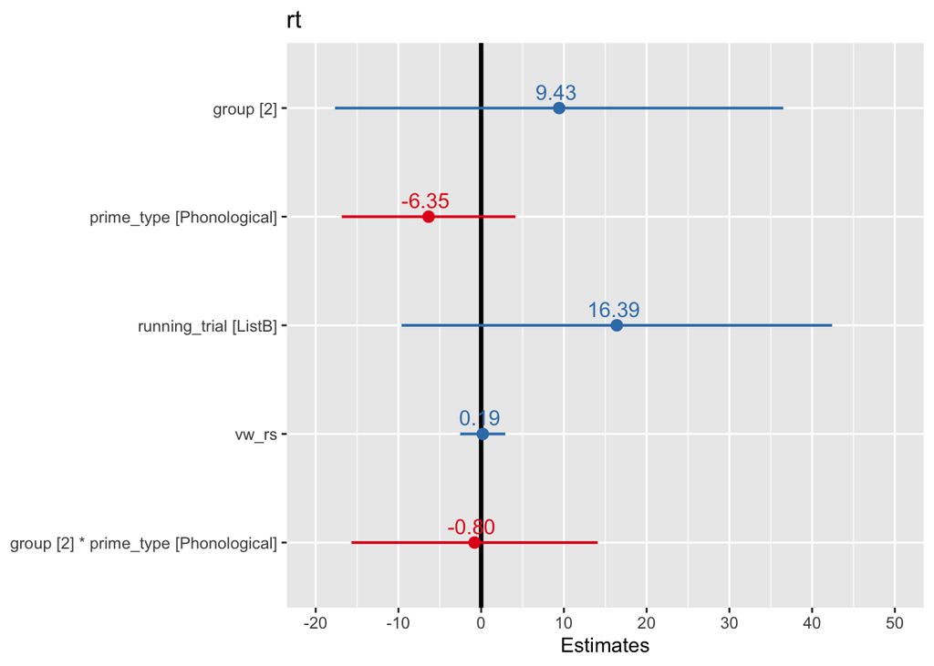

```r
plot_model(rt_model, vline.color = 'black',  show.values = TRUE)
```

### Accuracy Model with vw_rs

```r
acc_model <- lmer(data = df, accuracy ~ group * prime_type + running_trial +
                                 vw_rs + (1|subject) + (1|target_trial))

tab_model(acc_model)
```

|  | accuracy |  |  |
| --- | --- | --- | --- |
| Predictors | Estimates | CI | p |
| (Intercept) | 0.97 | 0.92 – 1.02 | **<0.001** |
| group [2] | -0.02 | -0.04 – -0.01 | **0.009** |
| prime_type [Phonological] | 0.01 | -0.00 – 0.03 | 0.079 |
| running_trial [ListB] | 0.01 | -0.01 – 0.02 | 0.361 |
| vw_rs | -0.00 | -0.00 – 0.00 | 0.947 |
| group [2] * prime_type [Phonological] | -0.00 | -0.02 – 0.02 | 0.921 |
| Random Effects |  |  |  |
| σ<sup>2</sup> | 0.03 |  |  |
| τ<sub>00</sub> <sub>target_trial</sub> | 0.00 |  |  |
| τ<sub>00</sub> <sub>subject</sub> | 0.00 |  |  |
| ICC | 0.07 |  |  |
| N <sub>subject</sub> | 36 |  |  |
| N <sub>target_trial</sub> | 104 |  |  |
| Observations | 3673 |  |  |
| Marginal R<sup>2</sup> / Conditional R<sup>2</sup> | 0.007 / 0.072 |  |  |

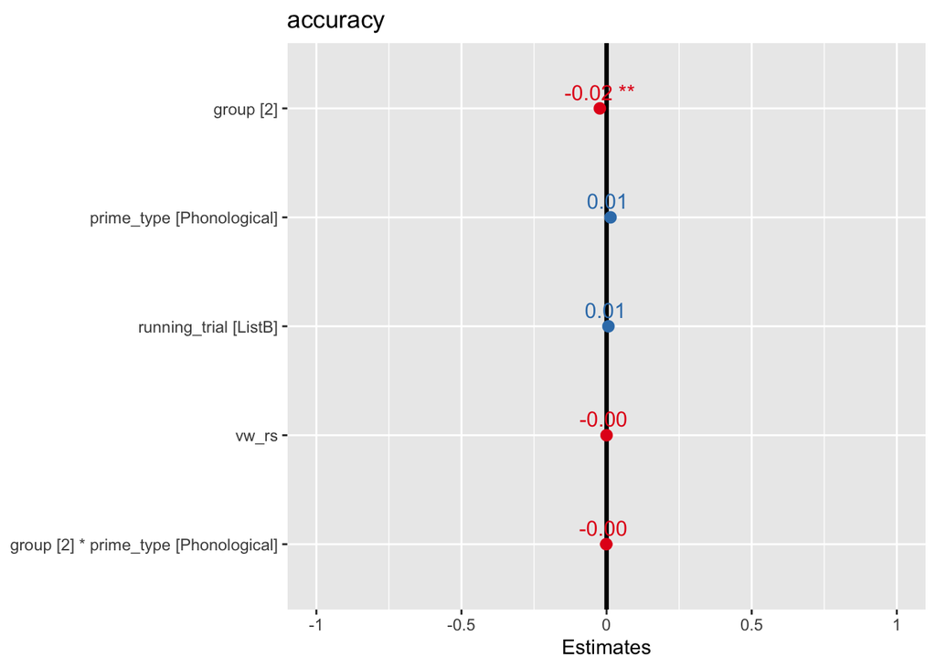

```r
plot_model(acc_model, vline.color = 'black',  show.values = TRUE)
```